# Integración GEIH–ECV, exposición tecnológica y mercado laboral en Colombia

Emparejamiento transversal, pseudo-panel y estimaciones del mercado laboral

Autor/a

Investigación: IA y Crecimiento Económico

Fecha de publicación

24 de noviembre de 2026

# 1 Introducción

La inteligencia artificial puede sustituir tareas o complementar las capacidades de los trabajadores. El enfoque basado en tareas permite medir la exposición de las ocupaciones a estas tecnologías sin equipararla con pérdidas de empleo observadas. La evidencia internacional, latinoamericana y colombiana ha estudiado tanto esa exposición potencial como sus relaciones con el empleo, los ingresos y la desigualdad. Este documento contribuye a esa discusión mediante la integración de la Gran Encuesta Integrada de Hogares y la Encuesta Nacional de Calidad de Vida, GEIH y ECV, para analizar conjuntamente la exposición ocupacional, el acceso digital y el uso reportado de inteligencia artificial en Colombia.

El índice de exposición ocupacional a la IA, AIOE, relaciona diez aplicaciones de IA con 52 habilidades de O*NET y pondera esas relaciones según la importancia y la presencia de cada habilidad en la ocupación (Felten et al., 2021). El índice mide exposición potencial. Webb (2020) propone medidas basadas en patentes y Eloundou et al. (2024) construyen una medida específica de exposición de tareas a modelos de lenguaje. Estas medidas se inscriben en la literatura sobre cambio técnico y empleo. Autor & Dorn (2013) documentan la polarización del empleo estadounidense entre ocupaciones de alta y baja cualificación. En la versión estática del modelo de Acemoglu & Restrepo (2018), con capital fijo y tecnología exógena, la automatización reduce el empleo y la participación del trabajo en el ingreso, y también puede reducir los salarios. Acemoglu & Restrepo (2022) vinculan el desplazamiento de tareas por la automatización con el aumento de la desigualdad salarial en Estados Unidos.

La evidencia internacional distingue exposición potencial de resultados observados. Frank et al. (2025) comparan varios índices ocupacionales, incluida la medida de Felten et al. de 2018, con datos de desempleo de Estados Unidos de 2010–2020. Su capacidad predictiva individual es limitada y mejora al combinarlos. Humlum & Vestergaard (2025) seleccionan ocupaciones con la medida de exposición directa E1 de Eloundou et al. (2024) y observan el uso de asistentes conversacionales en encuestas ligadas a registros daneses. Documentan cambios en las tareas y efectos promedio pequeños sobre el ingreso y las horas en el corto plazo.

Los estudios internacionales examinan distintas dimensiones de la IA, entre ellas la proporción de empleos expuestos, sus posibles efectos sobre la productividad y la difusión comercial de los modelos de lenguaje. Cazzaniga et al. (2024) estiman que cerca del 40 % del empleo mundial está expuesto a la IA, con diferencias importantes entre grupos de países. En un modelo basado en tareas, Acemoglu (2024) obtiene una ganancia de productividad total de los factores no superior al 0,66 % en diez años bajo su calibración de referencia. Esa cifra no es un pronóstico para Colombia. Jones (2026) destaca que las tareas difíciles de automatizar pueden limitar los aumentos agregados de productividad, mientras Demirer et al. (2026) documentan la expansión y la caída de precios del mercado de servicios de modelos de lenguaje. Estos trabajos ofrecen mecanismos para interpretar la difusión tecnológica y no tamaños de efecto directamente trasladables a las estimaciones del anexo.

En América Latina y el Caribe, Gmyrek et al. (2024) encuentran que entre 26 % y 38 % del empleo en América Latina y el Caribe está expuesto a la IA generativa, con diferencias de exposición por composición del empleo y barreras de acceso digital que pueden limitar sus beneficios. Esa relación descriptiva no demuestra que la informalidad cause una menor exposición. Azuara et al. (2024) aplican la metodología de Eloundou et al. (2024) a Chile, México y Perú y encuentran que, con un umbral bajo de exposición de tareas del 10 %, entre 74 % y 76 % de los empleos quedan expuestos, pero esa proporción cae a entre 6 % y 20 % con un umbral más exigente del 40 %; la exposición se concentra en mujeres, trabajadores con educación universitaria, empleo formal e ingresos más altos, lo que podría ampliar la desigualdad laboral regional en vez de reducirla. Ciaschi et al. (2025), combinando cuatro índices de exposición sobre encuestas de hogares de catorce países latinoamericanos, documentan la misma heterogeneidad, y proyectan que, sin políticas mitigadoras, el desplazamiento asociado produciría aumentos moderados, no abruptos, en pobreza y desigualdad.

En Colombia, las estimaciones de riesgo de automatización difieren por metodología y año de referencia. Morales Pantoja et al. (2023) aplican probabilidades de automatización a la GEIH de 2019 y sitúan cerca del 37 % de los empleos en la categoría de alto riesgo. Fernández & Suescún Salazar (2023) obtienen una proporción cercana al 57 % y muestran que la comparación entre empleo formal e informal depende de la medida utilizada. Mejía & Pabón (2023) estiman un riesgo cercano al 58 % para Colombia en su comparación andina. Estas cifras describen susceptibilidad técnica bajo determinados supuestos, no pérdidas de empleo observadas, y no son directamente equivalentes a los índices de exposición a IA empleados en este documento.

La literatura también estudia ajustes laborales efectivamente observados. Bonilla-Mejía et al. (2022) encuentran que durante la pandemia el empleo asalariado y las vacantes cayeron más y se recuperaron más lentamente en ocupaciones con mayor potencial de automatización. Medina & Posso (2018) documentan cambios en la composición ocupacional compatibles con polarización y cambio técnico. En el plano de política pública, los documentos CONPES 3975 y 4144 plantean la necesidad de fortalecer las capacidades digitales y preparar el mercado laboral para la transformación tecnológica (Departamento Nacional de Planeación, 2019, 2025). Estos antecedentes motivan distinguir exposición potencial, acceso digital y uso reportado de IA al analizar sus relaciones con los resultados laborales.

Este documento utiliza la GEIH para caracterizar las condiciones laborales y la ECV para incorporar información sobre bienestar y acceso digital. La imputación estadística reúne estos atributos a partir de características comunes de las personas. D’Orazio et al. (2006) y Ridder & Moffitt (2007) fundamentan esta combinación de fuentes bajo restricciones identificadoras, entre ellas la independencia condicional. La base armonizada cubre 2018–2025. Los cortes integrados permiten estimar los modelos individuales y los promedios por departamento, sexo y generación de nacimiento permiten construir el pseudo-panel de cohortes (Deaton, 1985; Verbeek, 2008). La Sección 2 describe la integración, sus diagnósticos y su alcance.

Las tablas econométricas de este artículo presentan AIOE en escala percentil como medida de exposición ocupacional para el desempleo, la no cotización pensional y el ingreso laboral. Las estimaciones clásicas también se calcularon por separado con los índices de IA de Webb, LLM, software y robots sobre muestras comparables. Sus coeficientes están disponibles en las salidas reproducibles.

La reproducibilidad numérica, la validez descriptiva de la integración y la identificación econométrica son dimensiones distintas. La coincidencia de cálculos no prueba independencia condicional ni causalidad. Por ello, las regresiones se interpretan como asociaciones condicionadas a su diseño según los supuestos y las limitaciones de cada ejercicio. Los códigos de procesamiento, emparejamiento, construcción de índices y estimación se documentan en las carpetas de reproducción del proyecto.

Este documento analiza la relación entre tecnología y resultados laborales en Colombia y contribuye a la literatura al contrastar la exposición ocupacional a la inteligencia artificial, su uso reportado y el acceso conjunto a computador e internet. La pregunta que orienta el análisis es cómo se relacionan estas dimensiones con el ingreso laboral, el desempleo y la no cotización pensional. Su aporte consiste en reunir información laboral y de condiciones de vida para examinar estas relaciones desde perspectivas individuales, territoriales y de cohortes, distinguiendo exposición potencial de acceso y uso observados.

Los resultados no muestran una asociación persistente de AIOE con ingreso y no cotización. En desempleo aparecen asociaciones negativas en algunos modelos de cohorte, pero el placebo significativo del DML-DiD limita su interpretación causal. El ejercicio instrumental presenta una primera etapa débil y la calibración de heterogeneidad detecta señal predictiva en desempleo. Dentro de una misma cohorte, 10 puntos porcentuales (pp) más en la proporción de personas que usan computador y viven en un hogar con internet, observada en la ECV, se asocian con un ingreso laboral real medio imputado 4,66 % mayor y una tasa de no cotización pensional imputada 3,39 pp menor. Ambas asociaciones conservan significancia con el bootstrap por departamento. La estimación para desempleo es imprecisa.

Después de esta introducción, la Sección 2 presenta la integración de las encuestas, los índices y el panel sintético. La Sección 3 describe la exposición tecnológica y las condiciones laborales en 2025. La Sección 4 presenta las estimaciones clásicas y el panel de TIC. La Sección 5 examina la exposición ocupacional y el uso reportado de IA con métodos de aprendizaje automático. La Sección 6 discute los hallazgos y la Sección 7 reúne las conclusiones y las limitaciones.

# 2 Datos y construcción de la base analítica

## 2.1 Integración de GEIH y ECV

El análisis utiliza una base sintética que integra anualmente la GEIH y la ECV entre 2018 y 2025. La GEIH actúa como fuente donante de la condición laboral, la ocupación, la cotización pensional y el ingreso laboral, mientras la ECV constituye la población receptora y conserva sus características individuales, condiciones de vida y acceso digital. La integración busca reunir atributos que no se observan conjuntamente con el detalle requerido en una sola encuesta. No enlaza identidades ni permite seguir a las mismas personas. Se utiliza la GEIH del trimestre septiembre–noviembre para aproximar su periodo de observación al de recolección de la ECV, aunque el solapamiento es parcial y pueden persistir diferencias estacionales. Los indicadores se ponderan con los factores de expansión de la encuesta receptora y los ingresos se expresan en pesos de octubre de 2025.

El fundamento del emparejamiento sigue a Rässler (2002), D’Orazio et al. (2006) y Ridder & Moffitt (2007). Sean $L$ los atributos laborales transferidos, $B$ los atributos de bienestar conservados y $C$ las características comunes. Las encuestas permiten aproximar las distribuciones condicionales de cada conjunto de atributos, pero no identifican por separado su distribución conjunta completa. Para identificarla se adopta el supuesto de independencia condicional

$$(L\perp B)\mid C,
\qquad
f(L,B\mid C)=f(L\mid C)f(B\mid C).
\tag{1}$$

La factorización describe la distribución conjunta que resulta bajo el supuesto de independencia condicional. En la práctica, el procedimiento usa $C$ para transferir los atributos laborales de un donante cercano sin utilizar los atributos exclusivos de ECV. La distribución de los valores asignados depende de los donantes disponibles y de su reutilización. Una asociación entre ingreso imputado y acceso digital puede reflejar, por ejemplo, que los grupos con mayor educación tienen mayores ingresos en GEIH y mayor acceso digital en ECV. La relación adicional dentro de un mismo grupo no se observa en las dos fuentes por separado. Los controles $X$ de cada regresión se eligen según la pregunta, el diseño y el momento de medición. Por ello, el conjunto usado para estimar puede diferir del que se usa para emparejar.

La imputación utiliza un procedimiento hot deck por vecino más cercano, descrito por D’Orazio et al. (2006) y revisado por Andridge & Little (2010). Las características comunes incluyen departamento, zona, sexo, edad, educación, jefatura, tamaño del hogar, pertenencia a la población de 15 años o más y trabajar como actividad principal. Departamento, zona y sexo delimitan la búsqueda inicial. Dentro de cada bloque se calcula una distancia euclidiana con seis coordenadas. La edad se divide entre 100 y la educación, armonizada en cinco niveles de cero a cuatro, entre cuatro. El tamaño del hogar se acota entre uno y quince integrantes y se divide entre diez. Los indicadores de jefatura, población en edad de trabajar y trabajo como actividad principal se multiplican por dos, cinco y tres, respectivamente. Estas escalas son decisiones de diseño que priorizan determinadas coincidencias, no parámetros estimados. Para cada receptor $i$, el donante y la transferencia se definen mediante

$$j^*(i)=\underset{j\in\mathcal D(i)}{\arg\min}
\left[\sum_{k\in K_i}(z_{ik}-z_{jk})^2\right]^{1/2},
\qquad \widehat L_i=L_{j^*(i)},
\tag{2}$$

donde $z$ reúne las seis características reescaladas, $\mathcal D(i)$ es el conjunto de donantes admisibles y $K_i$ contiene las dimensiones utilizables. Si falta educación en el receptor se omite esa dimensión. Cuando está observada, se priorizan donantes con educación disponible y solo se omite si ninguno dispone de ella. Las demás características deben ser válidas. Si el bloque inicial no tiene donantes, se amplía la búsqueda a otros departamentos conservando zona y sexo. Un mismo donante puede atender a varios receptores y sus atributos laborales se transfieren conjuntamente, preservando una combinación efectivamente observada. La pobreza y el ingreso per cápita transferidos, cuando están disponibles, proceden del donante asignado al jefe receptor y se comparten entre los integrantes de su hogar. Los campos sin información comparable permanecen ausentes.

La integración produce entre 227.998 y 289.558 receptores por año. La proporción ponderada que requiere donantes de otro departamento oscila entre 1,24 % y 3,05 %, y cada donante utilizado atiende, en promedio, entre 3,12 y 4,05 receptores. Esta reutilización genera dependencia entre los atributos imputados. La cobertura territorial también exige cautela. En 2018 y 2019, GEIH aporta donantes de 24 dominios territoriales frente a los 33 de ECV, de modo que algunos territorios dependen de donantes externos. Las tasas de desempleo imputadas superan las del conjunto donante en 2,39 y 1,20 pp en esos dos años. Desde 2020, las diferencias absolutas no exceden 0,56 pp. La conservación de los agregados, por tanto, no es uniforme durante todo el periodo.

La evaluación combina restricciones lógicas, contrastes distributivos y comparaciones laborales con información de ECV. En los ocho años no se asigna ocupación o ingreso laboral positivo a menores de 15 años, ni ingreso laboral positivo a personas clasificadas como desocupadas. Las validaciones detalladas, disponibles para 2022–2025, muestran acuerdos ponderados de ocupación entre 90,28 % y 90,47 %. Sin embargo, al excluir la actividad principal de la distancia, el acuerdo disminuye a 68,16 %–69,86 %, lo que revela su importancia y el carácter parcialmente interno de la evaluación. En hogares seleccionados, las variables no incluidas en la distancia presentan acuerdos pensionales de 64,66 %–65,43 % y de posición ocupacional de 47,79 %–49,66 %, con errores absolutos medios de 12,41–13,00 horas semanales. Estas comparaciones se restringen a personas identificadas como ocupadas en ambas fuentes y con respuestas comparables, y no representan a todos los ocupados. Tampoco deben extrapolarse a 2018–2021, para los que no se dispone de la misma validación detallada.

En conjunto, la integración permite estudiar determinados agregados y combinar dimensiones laborales y de acceso digital, pero no recupera la condición laboral verdadera de cada receptor ni valida automáticamente las relaciones entre atributos de ambas encuestas. La coherencia contable y la semejanza de algunos agregados coexisten con discrepancias individuales y con dependencia por reutilización de donantes. La inferencia de los modelos posteriores debe interpretarse reconociendo que la agrupación de errores no incorpora por sí sola toda la incertidumbre de imputación. El Anexo A, sección 2.1, presenta las reglas completas de armonización, los diagnósticos anuales y las comprobaciones de sensibilidad.

## 2.2 Medición de la exposición tecnológica

Se utilizan cinco indicadores ocupacionales que capturan dimensiones distintas de exposición tecnológica. AIOE, desarrollado por Felten et al. (2021), relaciona las habilidades de cada ocupación con capacidades de inteligencia artificial. Las medidas de Webb (2020) aproximan la exposición a IA, software y robots mediante la coincidencia entre tareas ocupacionales y descripciones de patentes. El indicador de Eloundou et al. (2024) evalúa la exposición de tareas a modelos de lenguaje. Se emplea su variante GPT-4 beta, que combina la exposición directa con la asociada al uso de software adicional, ponderando esta última a la mitad. Ninguna de estas medidas identifica adopción efectiva ni representa una probabilidad de sustitución del trabajador.

Las puntuaciones se trasladan a un catálogo fijo de 455 ocupaciones de la CIUO-08 A.C. mediante correspondencias entre las clasificaciones internacionales e ISCO-08 y los códigos colombianos. De ellas, 436 tienen correspondencia exacta por código, cuatro se aproximan mediante promedios del grupo de tres dígitos y 15 carecen de correspondencia. Cuando varios códigos internacionales convergen en una ocupación se utiliza su promedio simple. La disponibilidad de puntuaciones es menor que la de correspondencias. AIOE, IA de Webb, software y robots cubren 426 ocupaciones, frente a 396 de LLM. Los valores ausentes se conservan, sin sustituirlos por cero o por la media.

Para cada indicador $k$, la puntuación de la ocupación $o$ se transforma mediante su rango promedio $r_o^k$ entre las $N_k$ ocupaciones con información

$$I_o^{k,P}=\frac{r_o^k-1}{N_k-1}.
\tag{3}$$

La transformación expresa una posición relativa entre cero y uno, con igual peso para cada ocupación. Los empates reciben rango promedio y pueden impedir que se alcancen los extremos. El catálogo y la normalización se mantienen fijos entre años y submuestras. Las salidas reproducibles incluyen sensibilidades con la escala de mínimo y máximo y con una envolvente que toma el mayor valor de AIOE, IA de Webb y LLM entre las ocupaciones puntuadas en los tres índices. Aquí la escala de mínimo y máximo también se utiliza para verificar la clasificación por cuadrantes. Entre las 395 ocupaciones con cobertura común, las correlaciones de AIOE con LLM, IA de Webb y robots son 0,88, −0,02 y −0,78, respectivamente.

A los ocupados se asigna la puntuación de su ocupación actual y a los desocupados, la de su última ocupación, según la información transferida desde GEIH. La ocupación buscada se utiliza únicamente como alternativa de sensibilidad. Esta regla deja sin exposición a personas sin historia ocupacional identificable o sin puntuación disponible. Los modelos de exposición abarcan 2021–2025, pues las bases armonizadas de 2018–2020 no contienen códigos ocupacionales comparables. Para contrastar indicadores se exige cobertura en los cinco y controles válidos dentro de cada resultado. En las estimaciones clásicas de desempleo se retienen 541.805 de 573.501 observaciones, el 94,47 %. La muestra resultante no representa automáticamente a toda la fuerza laboral.

AIOE percentil es el indicador principal. Su exposición agregada para un departamento o cohorte $g$ se calcula con la composición del empleo de 2022

$$I_{g,2022}^{AIOE}=\sum_o s_{go,2022}I_o^{AIOE,P},
\qquad
s_{go,2022}=\frac{\sum_{i\in(g,o),2022}w_i\,1(i\in\mathcal V)}
{\sum_{i\in g,2022}w_i\,1(i\in\mathcal V)}.
\tag{4}$$

Para construir el índice de cada departamento o cohorte, primero se suma el empleo ponderado de cada ocupación en 2022 y se divide por el empleo ponderado del grupo. El numerador y el denominador se restringen al universo $\mathcal V$, integrado por ocupados con los cinco indicadores observados y factores de expansión positivos. Luego se multiplica la participación de cada ocupación por su AIOE percentil y se suman los aportes. En Bogotá, los vendedores y auxiliares de venta representan cerca del 5,48 % de los ocupados con cobertura común. Su AIOE de 0,5082 aporta alrededor de 0,0278 al índice total de **0,5444**. La exposición basal se mantiene fija para comparar la evolución de grupos con distinta exposición inicial. El Anexo A, sección 2.2, documenta el cálculo completo.

## 2.3 Construcción y evaluación del panel sintético

Las encuestas sucesivas se organizan como un pseudo-panel de cohortes siguiendo a Deaton (1985) y Verbeek (2008). Cada cohorte combina departamento de residencia, sexo y generación de nacimiento. Esta última se aproxima restando la edad al año de encuesta y se clasifica en cinco grupos, hasta 1964, 1965–1974, 1975–1984, 1985–1994 y desde 1995. Se incluyen personas de 15 años o más. La combinación de 33 dominios territoriales, dos sexos y cinco generaciones produce 330 cohortes y 2.640 observaciones entre 2018 y 2025. Los grupos se enlazan por estas características, sin volver a emparejar personas entre años.

Para una variable individual $Y_i$, el promedio de la cohorte $c$ en el año $t$ utiliza únicamente su universo válido $\mathcal U_Y$

$$\bar Y_{ct}=\frac{\sum_{i\in(c,t)}w_iY_i\,1(i\in\mathcal U_Y)}
{\sum_{i\in(c,t)}w_i\,1(i\in\mathcal U_Y)}.
\tag{5}$$

Los resultados laborales se construyen con los atributos imputados desde GEIH. El desempleo se calcula entre quienes integran la fuerza laboral y la no cotización pensional entre ocupados con respuesta afirmativa o negativa sobre cotización. Este último indicador aproxima una dimensión de la informalidad. Para el ingreso se calcula la media ponderada de los ingresos laborales reales positivos entre ocupados y luego su logaritmo natural. Los indicadores digitales se observan en ECV y se agregan sobre sus propios universos de respuesta válida. El TIC combinado exige uso personal de computador de escritorio o portátil y una conexión a internet en el hogar.

El panel contiene los tres resultados laborales en las 2.640 celdas. El número de personas encuestadas por celda varía entre 130 y 1.345, con mediana de 565. Sin embargo, el soporte de cada resultado es menor que el tamaño total de la cohorte. Los mínimos de receptores son 31 para desempleo y no cotización y 21 para ingreso, mientras los mínimos de donantes distintos son 20, 20 y 17. La cobertura ponderada mínima alcanza el 100 % de la fuerza laboral para desempleo, el 69,54 % de los ocupados para cotización válida y el 38,36 % para ingreso positivo. Son mínimos entre celdas, no porcentajes nacionales. Una comprobación independiente reproduce los tres resultados, sus receptores, donantes y coberturas en los ocho años, con diferencias exclusivamente de precisión numérica.

La disponibilidad de resultados no garantiza igual precisión ni composición estable. La reutilización de donantes reduce el soporte independiente y la residencia puede cambiar por migración. También pueden variar la selección muestral, la mortalidad y la entrada de jóvenes a la población elegible. Como sensibilidad para 2022–2025 se utiliza una variante con nacimiento estimado hasta 2007, que reduce esta última entrada y conserva 330 cohortes. Ese umbral no define un panel cerrado desde 2018. Los modelos ocupacionales utilizan 2021–2025 y el modelo de acceso digital emplea los ocho años. La exposición basal de 2022 se mantiene fija en los modelos que la requieren, mientras los resultados y controles se actualizan anualmente. Los diagnósticos completos se presentan en el Anexo A, sección 2.3.

# 3 Hechos estilizados de exposición tecnológica en 2025

Esta sección describe cómo se distribuye la exposición ocupacional a la IA y a los robots en 2025. Primero delimita la población que puede clasificarse con ambos indicadores y examina su cobertura. Luego compara los cuadrantes según su composición ocupacional, el desempleo, la no cotización pensional y el ingreso. Los ocupados y desocupados se concentran en el cuadrante de AIOE bajo y exposición a robots alta. La ocupación y los resultados laborales se imputan desde GEIH, y las cifras describen a la población clasificable con los factores de expansión de la ECV.

## 3.1 Indicadores y población clasificada

Para analizar conjuntamente la exposición ocupacional a la IA y a los robots, se cruzan AIOE y el índice de robots de Webb, ambos en percentiles fijos del catálogo ocupacional. AIOE figura en el eje vertical y robots en el horizontal. Las medianas no ponderadas de los dos percentiles son 0,50 entre las 426 ocupaciones con ambas puntuaciones. Los valores iguales al corte se clasifican como altos. El cuadrante I combina AIOE alto y robots bajo, el II reúne exposición alta en ambos, el III reúne exposición baja en ambos y el IV combina AIOE bajo y robots alto. Los cuadrantes describen combinaciones de exposición potencial.

Los ocupados se clasifican por su ocupación actual y los desocupados por la anterior. La cobertura ponderada es de 98,70 % y 85,76 %, respectivamente. La menor cobertura de los desocupados refleja la necesidad de identificar una ocupación previa puntuable y limita la generalización a quienes buscan empleo. Las participaciones se calculan por separado para cada población con los factores de expansión de ECV. A diferencia de la muestra econométrica común, este ejercicio exige únicamente AIOE y robots observados y no incorpora los filtros adicionales de las regresiones.

## 3.2 Distribución y condiciones laborales

La Figura 1 muestra una concentración en el cuadrante IV, que reúne el 53,43 % de los ocupados, el 52,55 % de los desocupados y el 66,69 % de los ocupados no cotizantes clasificables. La exposición alta a robots, cuadrantes II y IV, comprende el 63,54 % de los ocupados y el 64,69 % de los desocupados. En cambio, AIOE alto, cuadrantes I y II, abarca el 37,51 % y el 37,20 %. Por tanto, la mayoría presenta exposición elevada a robots, pero no a ambos indicadores simultáneamente. El área de cada burbuja representa la participación de una ocupación en la población de su panel y se calcula por separado para ocupados y desocupados. El color identifica el cuadrante. El I es azul petróleo, el II morado, el III gris verdoso y el IV ocre. Los porcentajes en rojo muestran qué parte de los ocupados no cotizantes pertenece a cada cuadrante.

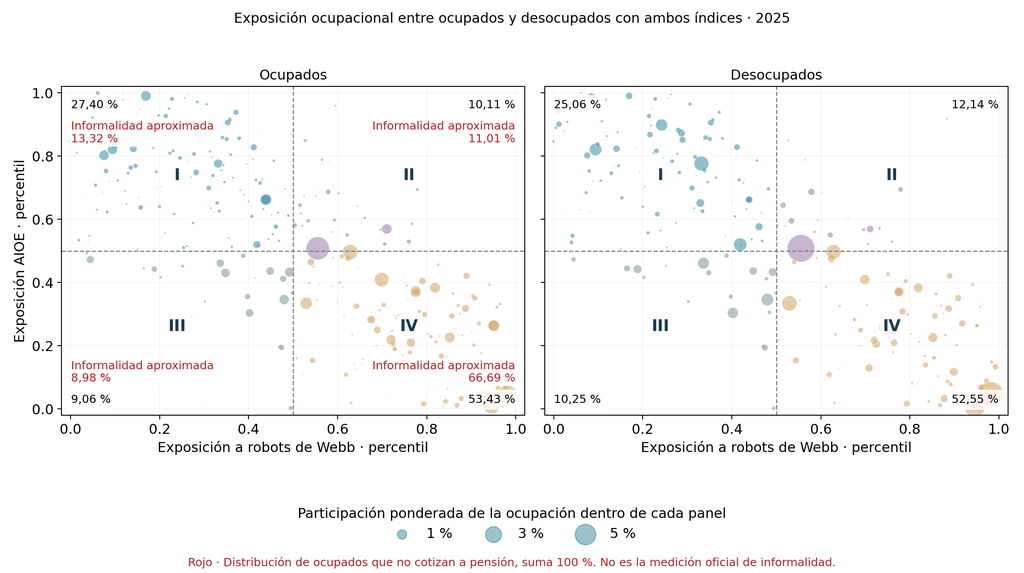

Figura 1: Distribución ocupacional según AIOE y robots de Webb, 2025. Los paneles corresponden a ocupados y desocupados clasificables. Los porcentajes en texto oscuro distribuyen cada población y los porcentajes en rojo distribuyen a los ocupados no cotizantes entre cuadrantes. Cada distribución suma 100 % y utiliza factores de expansión de ECV.

La Tabla 1 resume las condiciones laborales dentro de cada cuadrante. La no cotización es de 26,57 % en el I y 67,51 % en el IV, mientras el ingreso mediano positivo alcanza 2,30 y 1,40 millones de pesos, respectivamente. Las tasas de desempleo varían entre 5,85 % y 7,54 %. Estas tasas dividen los desocupados entre la suma de ocupados y desocupados del cuadrante y combinan ocupaciones actuales y anteriores. No estiman el riesgo de perder el empleo. Las diferencias de ingreso y protección pensional tampoco están ajustadas por composición ni constituyen pruebas de significancia.

Tabla 1: Distribución y condiciones laborales por cuadrante, 2025. Ingreso en pesos de octubre de 2025.

| Cuadrante | Ocupados % | Desocupados % | Desempleo % | No cotización % | Ingreso mediano |
| --- | --- | --- | --- | --- | --- |
| I | 27,40 | 25,06 | 5,85 | 26,57 | 2.300.000 |
| II | 10,11 | 12,14 | 7,54 | 58,98 | 1.423.500 |
| III | 9,06 | 10,25 | 7,13 | 53,66 | 1.423.500 |
| IV | 53,43 | 52,55 | 6,26 | 67,51 | 1.400.000 |

La concentración de los no cotizantes en ocupaciones expuestas a robots describe una vulnerabilidad potencial ante la automatización, pero no demuestra que la tecnología origine esa falta de protección. La no cotización se calcula entre ocupados con respuesta pensional válida y se presenta como aproximación a una dimensión de la informalidad, no como su medición oficial. Los índices próximos a uno indican posiciones altas de exposición relativa, no probabilidades cercanas al 100 % de sustitución.

## 3.3 Composición ocupacional y alcance

La composición ocupacional ayuda a interpretar los contrastes entre cuadrantes. En el I destacan gerentes de comercios, oficinistas y contadores. En el II, vendedores y auxiliares de venta concentran el 61,77 % del empleo del cuadrante. En el III sobresalen empleados de inventario, especialistas en belleza y peluqueros. En el IV, las principales ocupaciones son obreros agrícolas, personal doméstico, obreros de construcción y guardias de seguridad. Estas participaciones describen el empleo dentro de cada cuadrante, no su peso en el empleo nacional. El detalle de las cinco ocupaciones principales y el resto se conserva en el Anexo A, sección 3.3.

La clasificación es sensible a los umbrales. Al aplicar la escala de mínimo y máximo con sus respectivas medianas se obtiene la misma asignación para las 426 ocupaciones con ambas puntuaciones. Sin embargo, desplazar los cortes percentiles a 0,40 cambia de cuadrante al 21,16 % de los ocupados clasificables y llevarlos a 0,60 modifica al 14,66 %. Los cuadrantes no son categorías naturales de riesgo. La cobertura incompleta de los desocupados, la imputación de la ocupación y las diferencias de composición limitan su interpretación. Las encuestas tampoco permiten observar transiciones individuales entre cuadrantes. Estos hechos contextualizan las estimaciones posteriores sin identificar efectos causales de la exposición tecnológica.

# 4 Estimaciones econométricas clásicas y acceso a TIC

Esta sección examina la relación de la tecnología con el desempleo, la no cotización pensional y el ingreso laboral en Colombia. Primero presenta diferencias en diferencias, triples diferencias y modelos de cohorte con **AIOE percentil** para 2021–2025. Los contrastes con otros índices ocupacionales se encuentran en las salidas reproducibles. Después analiza el uso personal de computador junto con acceso a internet en el hogar mediante el panel de efectos fijos de cohorte de 2018–2025.

## 4.1 Diseño empírico y bases de datos

Las estimaciones se apoyan en dos estructuras de datos generadas a partir de la integración estadística.

1. **Microdatos integrados GEIH–ECV de 2021 a 2025.** El DiD y la triple diferencia utilizan la ocupación, los resultados laborales y la educación del mismo donante GEIH. La edad y su cuadrado, el sexo, la zona, la jefatura, el departamento y los factores de expansión provienen del receptor ECV. Se incluyen efectos fijos de año, departamento y grupo ocupacional a dos dígitos, con errores agrupados por ocupación a cuatro dígitos (Bertrand et al., 2004). La muestra común de las especificaciones principales exige controles válidos, respuestas TIC válidas y puntuaciones en los cinco índices. Las características de emparejamiento $C$ se describen en la Sección 2.1.
2. **Pseudo-panel de 330 cohortes de departamento, sexo y generación.** Los modelos de exposición ocupacional usan 1.650 celdas de 2021 a 2025. El panel de TIC utiliza 2.640 celdas de 2018 a 2025. La inferencia se agrupa por departamento. En esta sección, el bootstrap silvestre por departamento se aplica al panel de TIC.

Para un contraste de 0,1 unidades del índice percentil, $10\beta$ expresa los resultados binarios en puntos porcentuales y $100[\exp(0,1\beta)-1]\%$ expresa el contraste multiplicativo de ingreso. En los modelos individuales este último se refiere al ingreso geométrico condicional. En los modelos de cohorte la variable dependiente es el logaritmo de la media real de ingresos laborales positivos del grupo.

## 4.2 Diferencias en diferencias con exposición continua

Para examinar si la relación entre la exposición ocupacional a la IA y los resultados laborales cambió a partir de 2023, se estima una especificación de diferencias en diferencias con exposición continua. Su interpretación se apoya en el marco de Callaway et al. (2024).

$$Y_{iotd}=\alpha+\lambda_t+\eta_d+\gamma_{g(o)}+\rho I_o^k+\beta_k I_o^k Post_t+X_{it}'\theta+\varepsilon_{iotd}, \tag{6}$$

Aquí $Post_t$ vale uno entre 2023 y 2025. $I_o^k$ es el percentil fijo del índice $k$ para la ocupación $o$. Cada registro recibe la puntuación del oficio imputado en su corte anual, el actual para los ocupados y el último para los desocupados. $\rho$ mide la pendiente de exposición en 2021–2022 y $\beta_k$ mide cuánto cambia esa pendiente en 2023–2025.

Tabla 2: Modelo estático de diferencias en diferencias con AIOE percentil (2021–2025).

| Resultado | Índice | Coef. (EE) | IC 95% | p | N | G |
| --- | --- | --- | --- | --- | --- | --- |
| Desempleo | AIOE | -0.0081 (0.0107) | [-0.0291; 0.0130] | 0.4506 | 541.805 | 386 |
| No cotización | AIOE | 0.0200 (0.0149) | [-0.0093; 0.0492] | 0.1799 | 496.129 | 385 |
| Ingreso laboral | AIOE | 0.0170 (0.0240) | [-0.0302; 0.0642] | 0.4795 | 466.428 | 384 |

En la Tabla 2, 0,1 unidades más de AIOE se asocian, en el periodo posterior, con un cambio diferencial de −0,0808 pp en desempleo ($p=0{,}451$), +0,1997 pp en no cotización ($p=0{,}180$) y +0,1701 % en ingreso laboral ($p=0{,}480$). Los tres intervalos de confianza al 95 % incluyen cero.

La especificación con coeficientes anuales permite que la pendiente de exposición cambie en cada año. El año de referencia es 2022. $\rho$ mide la pendiente en ese año y cada $\beta_{ks}$ indica cuánto difiere la pendiente del año $s$ respecto a la de 2022. $\beta_{k,2021}$ compara los dos años previos y los coeficientes de 2023, 2024 y 2025 describen la evolución posterior.

$$Y_{iotd}=\alpha+\lambda_t+\eta_d+\gamma_{g(o)}+\rho I_o^k+\sum_{\substack{s=2021\\s\neq2022}}^{2025}\beta_{ks}I_o^k\mathbf{1}(t=s)+X_{it}'\theta+\varepsilon_{iotd}. \tag{7}$$

Tabla 3: DiD dinámico principal AIOE: contrastes anuales respecto a 2022.

| Resultado | Año de contraste | Coef. (EE) | IC 95% | p | N | G |
| --- | --- | --- | --- | --- | --- | --- |
| Desempleo | 2021 | 0.0086 (0.0178) | [-0.0264; 0.0437] | 0.628 | 541.805 | 386 |
| Desempleo | 2023 | -0.0034 (0.0130) | [-0.0290; 0.0221] | 0.7916 | 541.805 | 386 |
| Desempleo | 2024 | -0.0124 (0.0126) | [-0.0371; 0.0122] | 0.3224 | 541.805 | 386 |
| Desempleo | 2025 | 0.0048 (0.0111) | [-0.0170; 0.0266] | 0.6674 | 541.805 | 386 |
| No cotización | 2021 | -0.0066 (0.0186) | [-0.0432; 0.0300] | 0.724 | 496.129 | 385 |
| No cotización | 2023 | 0.0180 (0.0182) | [-0.0178; 0.0537] | 0.3234 | 496.129 | 385 |
| No cotización | 2024 | 0.0119 (0.0205) | [-0.0285; 0.0523] | 0.5621 | 496.129 | 385 |
| No cotización | 2025 | 0.0203 (0.0246) | [-0.0281; 0.0686] | 0.4101 | 496.129 | 385 |
| Ingreso laboral | 2021 | 0.0655 (0.0457) | [-0.0244; 0.1554] | 0.1528 | 466.428 | 384 |
| Ingreso laboral | 2023 | 0.0806 (0.0364) | [0.0089; 0.1522] | 0.02762 | 466.428 | 384 |
| Ingreso laboral | 2024 | 0.0565 (0.0397) | [-0.0216; 0.1346] | 0.1559 | 466.428 | 384 |
| Ingreso laboral | 2025 | 0.0103 (0.0384) | [-0.0653; 0.0859] | 0.7891 | 466.428 | 384 |

En la Tabla 3, el contraste de 2021 frente a 2022 no alcanza significancia al 5 % para ninguno de los tres resultados. Dos años previos permiten un solo contraste de tendencias preexistentes. Entre 2023 y 2025, el único coeficiente individual significativo al 5 % corresponde al ingreso laboral en 2023. Por 0,1 unidades más de AIOE, el cambio diferencial estimado respecto a 2022 es de +0,81 % ($p=0{,}028$, IC 95 % de +0,09 % a +1,53 %). En 2024 es de +0,57 % ($p=0{,}156$) y en 2025 de +0,10 % ($p=0{,}789$). Para ingreso, la prueba $F$ conjunta de los tres años posteriores da $p=0{,}126$. La evidencia apunta a una asociación puntual en 2023, con incertidumbre sobre su persistencia.

## 4.3 Triples diferencias según acceso digital y educación

La triple diferencia examina si el cambio posterior en la relación entre AIOE y los resultados laborales difiere según el uso de TIC o la educación universitaria.

$$\begin{aligned}
Y_{iotd}={}&\alpha+\lambda_t+\eta_d+\gamma_{g(o)}+X_{it}'\theta+\rho I_o^k+\delta H_{it} \\
&+\beta_k I_o^k Post_t+\zeta_k I_o^k H_{it}+\xi Post_t H_{it}+\tau_k I_o^k Post_t H_{it}+\varepsilon_{iotd},
\end{aligned} \tag{8}$$

El coeficiente $\tau_k$ mide cuánto difiere entre los grupos con y sin el habilitador el cambio en la pendiente que relaciona AIOE con el resultado laboral de 2021–2022 a 2023–2025. Se estima una especificación por habilitador.

Tabla 4: Triple diferencia de AIOE según TIC combinado.

| Resultado | Término | Coef. (EE) | IC 95% | p | N | G |
| --- | --- | --- | --- | --- | --- | --- |
| Desempleo | H=0 | -0.0105 (0.0168) | [-0.0436; 0.0225] | 0.5311 | 541.805 | 386 |
| Desempleo | H=1 | 0.0016 (0.0097) | [-0.0174; 0.0206] | 0.8698 | 541.805 | 386 |
| Desempleo | Interacción triple | 0.0121 (0.0188) | [-0.0248; 0.0491] | 0.5193 | 541.805 | 386 |
| No cotización | H=0 | 0.0255 (0.0181) | [-0.0101; 0.0610] | 0.16 | 496.129 | 385 |
| No cotización | H=1 | 0.0187 (0.0228) | [-0.0261; 0.0635] | 0.4128 | 496.129 | 385 |
| No cotización | Interacción triple | -0.0068 (0.0238) | [-0.0535; 0.0399] | 0.7754 | 496.129 | 385 |
| Ingreso laboral | H=0 | 0.0015 (0.0285) | [-0.0545; 0.0574] | 0.9593 | 466.428 | 384 |
| Ingreso laboral | H=1 | 0.0468 (0.0363) | [-0.0246; 0.1182] | 0.198 | 466.428 | 384 |
| Ingreso laboral | Interacción triple | 0.0454 (0.0398) | [-0.0329; 0.1236] | 0.255 | 466.428 | 384 |

En la Tabla 4, los intervalos de confianza al 95 % de la interacción triple y de los contrastes de ambos grupos incluyen cero para los tres resultados. El TIC combinado se observa en ECV, y la ocupación que determina AIOE y los resultados laborales se imputan desde GEIH. Entre registros con respuestas válidas, el grupo $H=0$ reúne a quienes no cumplen simultáneamente las dos condiciones de TIC. Dado el conjunto completo $C$, el supuesto de imputación implica que TIC no aporta información laboral adicional. La interacción estimada es exploratoria y puede recoger diferencias de composición, el carácter aproximado del emparejamiento y la diferencia entre $C$ y los controles de la regresión.

La comparación por educación universitaria utiliza educación, ocupación y resultados laborales observados conjuntamente en el donante GEIH. La educación armonizada también participa en el emparejamiento. Las categorías educativas de la regresión absorben el término principal del habilitador. En los tres resultados, los intervalos de confianza al 95 % de la interacción incluyen cero. El Anexo A presenta el cuadro correspondiente.

## 4.4 Modelos de cohortes y el panel de TIC (2018–2025)

El modelo de efectos fijos de cohorte (*Within*) utiliza la exposición basal de 2022 interactuada con el periodo posterior de 2023 a 2025. La diferencia larga compara 2025 con 2022. Por 0,1 unidades adicionales de AIOE basal, los contrastes de desempleo son de −1,035 y −0,849 pp, respectivamente ($p<0{,}05$). Estas asociaciones corresponden a promedios de cohorte y pueden reflejar cambios de composición.

El segundo ejercicio utiliza un panel balanceado de 330 cohortes observadas entre 2018 y 2025. Estima la asociación entre cambios en TIC y cambios en los resultados laborales dentro de la misma cohorte. Los efectos fijos de cohorte absorben características permanentes y los efectos fijos de año recogen cambios nacionales comunes.

$$Y_{c,t}=\alpha_c+\beta\,TIC_{c,t}+X_{c,t}'\theta+\lambda_t+u_{c,t}, \tag{9}$$

Aquí $TIC_{c,t}$ mide la proporción de personas de 15 años o más con respuesta válida en ECV que usan computador de escritorio o portátil y viven en un hogar con internet. Los controles también proceden de ECV e incluyen edad media, proporción rural, proporción con educación universitaria, tamaño medio del hogar y proporción de jefes de hogar. Los resultados laborales se construyen con datos imputados desde GEIH y cada uno conserva su universo válido. Los factores de expansión de ECV ponderan los promedios dentro de las celdas. En la regresión, cada celda de cohorte y año tiene el mismo peso.

Tabla 5: Efectos fijos en panel de cohortes TIC (2018–2025) e inferencia con bootstrap silvestre.

| Resultado | Coef. FE (EE dept.) | p agrupado | p bootstrap |
| --- | --- | --- | --- |
| Ingreso laboral | 0.4558 (0.0874) | 1.06e-05 | 0.0004 |
| Desempleo | -0.0760 (0.0464) | 0.111 | 0.14 |
| No cotización pensional | -0.3394 (0.1108) | 0.00441 | 0.0002 |

En la Tabla 5, 10 pp más en la proporción con TIC combinado observada en ECV se asocian, dentro de una misma cohorte, con un ingreso laboral real medio imputado 4,66 % mayor ($p=0{,}0004$) y una tasa de no cotización pensional imputada 3,39 pp menor ($p=0{,}0002$). Para el desempleo imputado, la asociación estimada es de −0,76 pp ($p=0{,}1403$). Los valores $p$ corresponden al bootstrap silvestre por departamento con 9.999 repeticiones, aplicado al panel ya imputado.

La agregación permite estudiar cómo se mueven conjuntamente los promedios de la cohorte. Los cambios de composición y de soporte de la imputación también pueden contribuir a esa relación, en particular en 2018 y 2019, cuando GEIH aportó donantes de 24 dominios territoriales para los 33 de ECV. Los efectos fijos absorben las características permanentes y los cambios nacionales comunes. Los choques específicos de cada cohorte y la posibilidad de que mayores ingresos faciliten el acceso digital limitan la interpretación causal.

# 5 Aprendizaje automático aplicado a exposición y uso reportado de IA

Los métodos semiparamétricos de esta sección permiten estimar relaciones flexibles con las covariables. Siguiendo a Chernozhukov et al. (2018), la partición cruzada obtiene predicciones fuera de muestra y reduce la sensibilidad al sobreajuste. La identificación depende de los supuestos de cada diseño y de cómo se construyeron sus variables.

## 5.1 DML-DiD con exposición continua

Se estima una regresión parcialmente lineal sobre los cambios de las cohortes del pseudo-panel. Para cada cohorte, $\Delta Y_c$ es la diferencia entre el promedio del resultado laboral imputado en 2023–2025 y el de 2021–2022. Dentro de cada periodo, los años se ponderan por el número de receptores en edad de trabajar. La exposición basal $I_{c,2022}^{AIOE}$ se calcula con la composición del empleo de la cohorte en 2022, a partir de las ocupaciones imputadas desde GEIH.

$$\Delta Y_c=\theta I_{c,2022}^{AIOE}+g(X_c)+\varepsilon_c, \qquad I_{c,2022}^{AIOE}=m(X_c)+v_c, \tag{10}$$

Entre cohortes con las mismas características $X_c$, $\ell(X_c)=\mathbb{E}[\Delta Y_c\mid X_c]$ representa el cambio laboral esperado y $m(X_c)=\mathbb{E}[I_{c,2022}^{AIOE}\mid X_c]$ representa la exposición basal esperada. Los controles $X_c$ se construyen con datos de ECV de 2021–2022 y resumen la edad, la ruralidad, la educación universitaria, el tamaño del hogar y la jefatura. Las funciones con gorro, $\widehat\ell$ y $\widehat m$, son las estimaciones de esas medias condicionales. Cada función se ajusta por separado mediante potenciación del gradiente basada en histogramas, que combina en secuencia árboles de decisión para regresión. El ajuste admite hasta 80 iteraciones, con un máximo de tres hojas por árbol y un mínimo de 30 cohortes de entrenamiento por hoja.

La partición cruzada distribuye los departamentos en cinco bloques y mantiene juntas las cohortes de cada territorio. El superíndice $-k(c)$ indica que las predicciones para la cohorte $c$ se obtienen con modelos entrenados en los otros cuatro bloques. Los residuos se calculan restando cada predicción fuera de muestra del cambio laboral o de la exposición correspondiente. El estimador ortogonal relaciona esos residuos. El peso $q_c$, utilizado en el ajuste de las funciones auxiliares y en el estimador, es el número medio de receptores en edad de trabajar de la cohorte durante los años comparados.

$$\widehat\theta_{DML-DiD}=\frac{\sum_c q_c\widetilde I_c\widetilde{\Delta Y}_c}{\sum_c q_c\widetilde I_c^2}, \qquad \widetilde{\Delta Y}_c=\Delta Y_c-\widehat\ell^{(-k(c))}(X_c), \qquad \widetilde I_c=I_{c,2022}^{AIOE}-\widehat m^{(-k(c))}(X_c). \tag{11}$$

Tabla 6: Estimación DML-DiD continuo entre 2021–2022 y 2023–2025.

| Resultado | Contraste | Coeficiente (EE) | IC 95% | p-valor | Cohortes |
| --- | --- | --- | --- | --- | --- |
| Ingreso laboral | Pre 2021–2022 / Post 2023–2025 | -0.2631 (0.1483) | [-0.5653; +0.0391] | 0.0856 | 330 |
| No cotización | Pre 2021–2022 / Post 2023–2025 | +0.0202 (0.0677) | [-0.1176; +0.1581] | 0.7667 | 330 |
| Desempleo | Pre 2021–2022 / Post 2023–2025 | -0.1615 (0.0496) | [-0.2625; -0.0605] | 0.0027 | 330 |

En la Tabla 6, los intervalos de confianza al 95 % incluyen cero para el ingreso laboral real ($\theta=-0{,}2631$, $p=0{,}0856$) y la no cotización ($\theta=0{,}0202$, $p=0{,}7667$). Para el desempleo, el coeficiente es negativo ($\theta=-0{,}1615$, $p=0{,}0027$), pero el placebo entre 2021 y 2022 también es negativo y significativo ($\theta=-0{,}1428$, $p=0{,}0089$). La relación que se observa antes de 2023 debilita la interpretación causal del resultado posterior.

## 5.2 Uso reportado de IA y variables instrumentales (DML-IV)

El tratamiento es el uso reportado de herramientas de IA por internet en la ECV de 2025. El instrumento, AIOE, se asigna con la ocupación del donante GEIH, del que también proceden los resultados laborales imputados. En este modelo, los controles de educación y asistencia educativa corresponden al receptor ECV.

Tabla 7: DML-IV para uso reportado de IA en corte transversal 2025.

| Resultado | Instrumento (Z) | Coeficiente IV (EE) | p convencional | F primera etapa | Personas | Ocupaciones |
| --- | --- | --- | --- | --- | --- | --- |
| Ingreso laboral | AIOE | +3,4609 (23,9090) | 0,8850 | 0,3463 | 101.071 | 386 |
| No cotización | AIOE | -67,2041 (973,6200) | 0,9450 | 0,0048 | 103.834 | 386 |
| Desempleo | AIOE | -123,2051 (2480,2007) | 0,9604 | 0,0025 | 111.837 | 388 |

En la Tabla 7, el estadístico $F$ de la primera etapa residualizada es inferior a 0,35 en los tres resultados. Esto indica una relación débil entre el AIOE asignado y el uso de IA observado en la base integrada. Los coeficientes son sensibles a las particiones de muestra y la relación de primera etapa depende del emparejamiento. Una interpretación causal requeriría además justificar la exclusión, ya que la ocupación puede relacionarse con los resultados laborales por vías distintas del uso de IA.

## 5.3 Heterogeneidad exploratoria con R-learner

El R-learner adapta la pérdida residual de Nie & Wager (2021) para explorar cómo varía la pendiente del regresor $D_i=AIOE_i\,Post_i$, donde $Post_i=1$ desde 2023. AIOE se asigna a partir de la ocupación del donante GEIH, que también aporta los resultados laborales y el control educativo. Entre los controles se incluye el acceso digital observado en ECV. La especificación agrupa los años de análisis y puede recoger diferencias de periodo o composición.

Tabla 8: Evaluación de la heterogeneidad de pendientes estimadas con R-learner.

| Resultado | BLP β (p) | Con TIC | Sin TIC | Universitaria o posgrado | Resto de niveles | Mujeres | Hombres | Jóvenes ≤29 | Adultos 30-49 |
| --- | --- | --- | --- | --- | --- | --- | --- | --- | --- |
| Ingreso laboral | +0.0317 (0.851) | +0.148 | +0.331 | +0.140 | +0.303 | +0.294 | +0.256 | +0.267 | +0.223 |
| No cotización | -0.0435 (0.565) | -0.068 | -0.112 | -0.077 | -0.102 | -0.036 | -0.140 | -0.094 | -0.089 |
| Desempleo | +0.2056 (0.006) | -0.052 | -0.098 | -0.025 | -0.097 | -0.118 | -0.057 | -0.103 | -0.078 |

En la Tabla 8, la calibración mediante el mejor predictor lineal (BLP) encuentra una señal predictiva de heterogeneidad para desempleo ($p=0{,}0063$). Para ingreso laboral ($p=0{,}851$) y no cotización ($p=0{,}565$), la evidencia resulta imprecisa. La prueba evalúa la señal del predictor en conjunto. Atribuir las diferencias a características concretas o a un mecanismo causal exige evidencia adicional.

# 6 Evaluación integrada de resultados y discusión

Las estimaciones de AIOE para 2021–2025 ofrecen evidencia limitada de cambios persistentes en los resultados laborales. El DiD dinámico encuentra una asociación puntual con el ingreso en 2023. En desempleo, algunos modelos de cohorte arrojan pendientes negativas. El placebo significativo del DML-DiD exige cautela al atribuir esos cambios a la difusión de la IA. Las triples diferencias aportan comparaciones exploratorias según acceso digital y educación.

El ejercicio de variables instrumentales estudia el uso reportado de IA y presenta una primera etapa débil. Por su parte, el R-learner detecta una señal predictiva de heterogeneidad en desempleo. En conjunto, estos resultados delimitan qué puede inferirse sobre la exposición y el uso observado a partir de las fuentes disponibles.

El panel de TIC vincula cambios en la proporción con TIC combinado observada en ECV con cambios en los resultados laborales imputados desde GEIH. Las asociaciones con mayor ingreso laboral real medio y menor no cotización conservan significancia con el bootstrap por departamento. La estimación para desempleo es imprecisa ($p=0{,}1403$).

# 7 Conclusiones y limitaciones

Este trabajo caracteriza la exposición ocupacional a la IA, el acceso a TIC y las condiciones laborales en Colombia. Integra cortes anuales de GEIH y ECV y construye un pseudo-panel de cohortes para 2018–2025.

Las estimaciones ofrecen evidencia limitada sobre cambios laborales persistentes asociados con la exposición ocupacional a la IA en 2021–2025. Entre los resultados del panel de TIC, las asociaciones con mayor ingreso y menor no cotización son estadísticamente más precisas que la estimación de desempleo. Su interpretación se limita a cambios dentro de las cohortes bajo los controles incorporados.

- **Independencia condicional.** Los diagnósticos documentan el soporte y la coherencia de la integración. Las asociaciones entre atributos exclusivos de GEIH y ECV pueden reflejar diferencias en las características de emparejamiento. La relación adicional entre esos atributos en personas con el mismo $C$ depende del supuesto de imputación.
- **Composición de las cohortes.** Las observaciones son promedios de grupo. Cambios en quién integra cada cohorte y choques específicos de su territorio pueden influir en las asociaciones. La cobertura territorial del conjunto donante de 2018 y 2019 merece especial atención.
- **Ventana de observación.** Las estimaciones de exposición se concentran en 2021–2025. Evaluar cambios laborales de más largo plazo requiere una ventana más amplia.

Las asociaciones del panel de TIC motivan evaluar con diseños específicos los programas de acceso y uso digital. La exposición ocupacional y la adopción de IA requieren mediciones propias para evaluar sus consecuencias laborales.

## Referencias

Acemoglu, D. (2024). *The Simple Macroeconomics of AI* (Working Paper 32487). National Bureau of Economic Research. https://www.nber.org/papers/w32487

Acemoglu, D., & Restrepo, P. (2018). The Race between Man and Machine: Implications of Technology for Growth, Factor Shares, and Employment. *American Economic Review*, *108*(6), 1488-1542. https://doi.org/10.1257/aer.20160696

Acemoglu, D., & Restrepo, P. (2022). Tasks, Automation, and the Rise in US Wage Inequality. *Econometrica*, *90*(5), 1973-2016. https://doi.org/10.3982/ECTA19815

Andridge, R. R., & Little, R. J. A. (2010). A Review of Hot Deck Imputation for Survey Non-response. *International Statistical Review*, *78*(1), 40-64. https://doi.org/10.1111/j.1751-5823.2010.00103.x

Autor, D. H., & Dorn, D. (2013). The Growth of Low-Skill Service Jobs and the Polarization of the US Labor Market. *American Economic Review*, *103*(5), 1553-1597. https://doi.org/10.1257/aer.103.5.1553

Azuara, O., Ripani, L., & Torres Ramirez, E. (2024). *AI and the Increase of Productivity and Labor Inequality in Latin America: Potential Impact of Large Language Models on Latin American Workforce* (Discussion Paper IDB-DP-01076). Inter-American Development Bank. https://doi.org/10.18235/0013152

Bertrand, M., Duflo, E., & Mullainathan, S. (2004). How Much Should We Trust Differences-in-Differences Estimates? *The Quarterly Journal of Economics*, *119*(1), 249-275. https://doi.org/10.1162/003355304772839588

Bonilla-Mejía, L., Flórez, L. A., Hermida, D., Lasso-Valderrama, F., Morales, L. F., Ospina-Tejeiro, J. J., & Pulido, J. (2022). *Is the Covid-19 Pandemic Fast-Tracking Automation in Developing Countries? Evidence from Colombia* (BIS Working Paper 1048). Bank for International Settlements.

Callaway, B., Goodman-Bacon, A., & Sant’Anna, P. H. C. (2024). *Difference-in-Differences with a Continuous Treatment* (NBER Working Paper No. 32117). National Bureau of Economic Research. https://doi.org/10.3386/w32117

Cazzaniga, M., Jaumotte, F., Li, L., Melina, G., Panton, A. J., Pizzinelli, C., Rockall, E. J., & Tavares, M. M. (2024). *Gen-AI: Artificial Intelligence and the Future of Work* (Staff Discussion Note SDN/2024/001). International Monetary Fund. https://doi.org/10.5089/9798400262548.006

Chernozhukov, V., Chetverikov, D., Demirer, M., Duflo, E., Hansen, C., Newey, W., & Robins, J. (2018). Double/Debiased Machine Learning for Treatment and Structural Parameters. *The Econometrics Journal*, *21*(1), C1-C68. https://doi.org/10.1111/ectj.12097

Ciaschi, M., Falcone, G., Garganta, S., Gasparini, L., Bertín, O., & Ramírez-Leira, L. (2025). *The Potential Distributive Impact of AI-driven Labor Changes in Latin America* (Working Paper IDB-WP-14253). Inter-American Development Bank. https://doi.org/10.18235/0013677

D’Orazio, M., Di Zio, M., & Scanu, M. (2006). *Statistical Matching: Theory and Practice*. Wiley. https://doi.org/10.1002/0470023554

Deaton, A. (1985). Panel Data from Time Series of Cross-Sections. *Journal of Econometrics*, *30*(1–2), 109-126. https://doi.org/10.1016/0304-4076(85)90134-4

Demirer, M., Fradkin, A., & Tadelis, N. (2026). The Emerging Market for Intelligence: How Firms Buy and Sell AI. *Journal of Economic Perspectives*, *40*(3), 23-46. https://doi.org/10.1257/jep.20261506

Departamento Nacional de Planeación. (2019). *Política Nacional para la Transformación Digital e Inteligencia Artificial* (Documento CONPES 3975). Departamento Nacional de Planeación.

Departamento Nacional de Planeación. (2025). *Política Nacional de Inteligencia Artificial* (Documento CONPES 4144). Departamento Nacional de Planeación.

Eloundou, T., Manning, S., Mishkin, P., & Rock, D. (2024). GPTs are GPTs: Labor Market Impact Potential of LLMs. *Science*, *384*(6702), 1306-1308. https://doi.org/10.1126/science.adj0998

Felten, E. W., Raj, M., & Seamans, R. (2021). Occupational, Industry, and Geographic Exposure to Artificial Intelligence: A Novel Dataset and Its Potential Uses. *Strategic Management Journal*, *42*(12), 2195-2217. https://doi.org/10.1002/smj.3286

Fernández, C., & Suescún Salazar, C. (2023). *Automation of the Labor Force and Informality with Focus on the Colombian Case*. Fedesarrollo.

Frank, M. R., Ahn, Y.-Y., & Moro, E. (2025). AI Exposure Predicts Unemployment Risk: A New Approach to Technology-Driven Job Loss. *PNAS Nexus*, *4*, pgaf107. https://doi.org/10.1093/pnasnexus/pgaf107

Gmyrek, P., Winkler, H., & Garganta, S. (2024). *Buffer or Bottleneck? Employment Exposure to Generative AI and the Digital Divide in Latin America* (ILO Working Paper 121). International Labour Organization; The World Bank. https://doi.org/10.54394/TFZY7681

Humlum, A., & Vestergaard, E. (2025). *Still Waters, Rapid Currents: Early Labor Market Transformation under Generative AI* (No. 33777). NBER.

Jones, C. I. (2026). AI and Our Economic Future. *Journal of Economic Perspectives*, *40*(3), 3-22. https://doi.org/10.1257/jep.20261505

Medina, C., & Posso, C. (2018). Cambio técnico y polarización en el mercado laboral. Evidencia para Colombia. *El Trimestre Económico*, *85*(338), 365-410. https://doi.org/10.20430/ete.v85i338.349

Mejía, L. F., & Pabón, C. (2023). *COVID-19 y riesgo de automatización en el mercado laboral de los países andinos*. Fedesarrollo; Banco Interamericano de Desarrollo.

Morales Pantoja, A. J., Atis Ortega, K. L., & Fajardo Hoyos, C. L. (2023). Risk of Automation of Jobs in Colombia: An Analysis of the Determinants of Workers’ Vulnerability to Technological Disruption. *Revista Facultad de Ciencias Económicas*, *31*(2), 159-172. https://doi.org/10.18359/rfce.6723

Nie, X., & Wager, S. (2021). Quasi-Oracle Estimation of Heterogeneous Treatment Effects. *Biometrika*, *108*(2), 299-319. https://doi.org/10.1093/biomet/asaa076

Rässler, S. (2002). *Statistical Matching: A Frequentist Theory, Practical Applications, and Alternative Bayesian Approaches* (Vol. 168). Springer-Verlag. https://doi.org/10.1007/978-1-4613-0053-3

Ridder, G., & Moffitt, R. (2007). The Econometrics of Data Combination. En *Handbook of Econometrics* (Vol. 6, pp. 5469-5547). Elsevier. https://doi.org/10.1016/S1573-4412(07)06075-X

Verbeek, M. (2008). Pseudo-Panels and Repeated Cross-Sections. En L. Mátyás & P. Sevestre (Eds.), *The Econometrics of Panel Data* (3rd ed., Vol. 46, pp. 369-383). Springer. https://doi.org/10.1007/978-3-540-75892-1_11

Webb, M. (2020). *The Impact of Artificial Intelligence on the Labor Market* [Working Paper]. Stanford University. https://papers.ssrn.com/sol3/papers.cfm?abstract_id=3482150